# Clean Multiple Regression Code

### Width

```r
width_reg_ih <- lmer(width_i ~ width_h * species + (1 | individual_id), data = width_all)
summary(width_reg_ih)
```

```
## Linear mixed model fit by REML. t-tests use Satterthwaite's method [
## lmerModLmerTest]
## Formula: width_i ~ width_h * species + (1 | individual_id)
##    Data: width_all
##
## REML criterion at convergence: 220.3
##
## Scaled residuals:
##     Min      1Q  Median      3Q     Max
## -3.4570 -0.3541 -0.0043  0.4800  3.7396
##
## Random effects:
##  Groups        Name        Variance Std.Dev.
##  individual_id (Intercept) 0.02578  0.1606
##  Residual                  0.17125  0.4138
## Number of obs: 162, groups:  individual_id, 54
##
## Fixed effects:
##                       Estimate Std. Error         df t value Pr(>|t|)
## (Intercept)           0.272115   0.236478 126.740299   1.151 0.252021
## width_h               1.151373   0.083930 138.419125  13.718  < 2e-16 ***
## speciesCC            -0.620575   0.342832 123.037547  -1.810 0.072714 .
## speciesCO             0.446118   0.415375 139.326962   1.074 0.284674
## speciesCYOS           0.471786   0.340900 109.731365   1.384 0.169185
## speciesDL             0.246742   1.344039 112.207950   0.184 0.854673
## speciesDP            -0.523920   0.296015 118.418791  -1.770 0.079316 .
## speciesEGME           0.284999   0.408095 132.278111   0.698 0.486176
## speciesGR            -0.122673   0.502592 136.144808  -0.244 0.807536
## speciesNAND          -0.126218   0.356086 102.952742  -0.354 0.723719
## speciesPOLA          -0.433035   1.673731 107.929898  -0.259 0.796341
## speciesR             -0.123335   0.301637 110.557969  -0.409 0.683415
## width_h:speciesCC     0.182215   0.088658 138.359422   2.055 0.041735 *
## width_h:speciesCO    -0.288921   0.122342 134.718497  -2.362 0.019630 *
## width_h:speciesCYOS  -0.090180   0.097947 139.835800  -0.921 0.358791
## width_h:speciesDL    -0.373692   1.575169 100.246932  -0.237 0.812956
## width_h:speciesDP     0.467741   0.135512 135.940672   3.452 0.000743 ***
## width_h:speciesEGME  -0.196477   0.145111 139.328362  -1.354 0.177934
## width_h:speciesGR     0.008776   0.243724 134.944567   0.036 0.971328
## width_h:speciesNAND  -0.053593   0.107060 134.929959  -0.501 0.617479
## width_h:speciesPOLA   0.158052   0.600841 101.038027   0.263 0.793046
## width_h:speciesR     -0.028081   0.091096 139.271757  -0.308 0.758347
## ---
## Signif. codes:  0 '***' 0.001 '**' 0.01 '*' 0.05 '.' 0.1 ' ' 1
```

```
##
## Correlation matrix not shown by default, as p = 22 > 12.
## Use print(x, correlation=TRUE)  or
##     vcov(x)        if you need it
```

```r
width_reg_ih_nospecies <- lmer(width_i ~ width_h + (1 | individual_id), data = width_all)
summary(width_reg_ih_nospecies)
```

```
## Linear mixed model fit by REML. t-tests use Satterthwaite's method [
## lmerModLmerTest]
## Formula: width_i ~ width_h + (1 | individual_id)
##    Data: width_all
##
## REML criterion at convergence: 281.4
##
## Scaled residuals:
##     Min      1Q  Median      3Q     Max
## -2.7952 -0.4539  0.0449  0.3985  4.8626
##
## Random effects:
##  Groups        Name        Variance Std.Dev.
##  individual_id (Intercept) 0.1262   0.3552
##  Residual                  0.2309   0.4805
## Number of obs: 162, groups:  individual_id, 54
##
## Fixed effects:
##              Estimate Std. Error        df t value Pr(>|t|)
## (Intercept)   0.08737    0.08547  98.88700   1.022    0.309
## width_h       1.20652    0.01892 154.81287  63.760   <2e-16 ***
## ---
## Signif. codes:  0 '***' 0.001 '**' 0.01 '*' 0.05 '.' 0.1 ' ' 1
##
## Correlation of Fixed Effects:
##         (Intr)
## width_h -0.686
```

### Perimeter

```r
perimeter_reg_ih <- lmer(per_i ~ per_h * species + (1 | individual_id), data = perimeter_all)
summary(perimeter_reg_ih)
```

```
## Linear mixed model fit by REML. t-tests use Satterthwaite's method [
## lmerModLmerTest]
## Formula: per_i ~ per_h * species + (1 | individual_id)
##    Data: perimeter_all
##
## REML criterion at convergence: 1361.8
##
## Scaled residuals:
##     Min      1Q  Median      3Q     Max
## -2.0987 -0.2817 -0.0422  0.1080  4.7679
##
## Random effects:
##  Groups        Name        Variance Std.Dev.
##  individual_id (Intercept) 225.6    15.02
##  Residual                  501.2    22.39
## Number of obs: 153, groups:  individual_id, 52
##
## Fixed effects:
##                    Estimate Std. Error        df t value Pr(>|t|)
## (Intercept)         2.59684   13.77863  88.26129   0.188 0.850942
## per_h               1.19298    0.10995 125.45680  10.850  < 2e-16 ***
## speciesCC          -6.82156   19.70908 103.74382  -0.346 0.729959
## speciesCO         -19.35573   23.91988 114.13986  -0.809 0.420089
## speciesCYOS         6.64731   21.07977 109.76272   0.315 0.753102
## speciesDP          34.33115   17.91760  88.87197   1.916 0.058572 .
## speciesEGME        -2.02207   19.61561 105.50238  -0.103 0.918091
## speciesGR           1.05566   22.86537  80.61552   0.046 0.963290
## speciesNAND       -19.63704   47.84044  78.89181  -0.410 0.682574
## speciesPOLA       147.31861   41.95239 132.97267   3.512 0.000609 ***
## speciesR           -1.44377   18.60890  89.93418  -0.078 0.938330
## per_h:speciesCC     0.11400    0.22636 126.28471   0.504 0.615398
## per_h:speciesCO     0.18647    0.24758 132.38146   0.753 0.452687
## per_h:speciesCYOS  -0.11782    0.13820 132.81018  -0.853 0.395437
## per_h:speciesDP     0.10835    0.13834 122.61000   0.783 0.434995
## per_h:speciesEGME  -0.09324    0.29545 110.83387  -0.316 0.752910
## per_h:speciesGR     0.03776    0.19031 116.97364   0.198 0.843049
## per_h:speciesNAND   0.20992    0.35881  95.46443   0.585 0.559902
## per_h:speciesPOLA  -1.03952    0.28146 106.94185  -3.693 0.000351 ***
## per_h:speciesR      0.09234    0.17917 132.89084   0.515 0.607163
## ---
## Signif. codes:  0 '***' 0.001 '**' 0.01 '*' 0.05 '.' 0.1 ' ' 1
```

```
##
## Correlation matrix not shown by default, as p = 20 > 12.
## Use print(x, correlation=TRUE)  or
##     vcov(x)        if you need it
```

```r
perimeter_reg_ih_nospecies <- lmer(per_i ~ per_h + (1 | individual_id), data = perimeter_all)
summary(perimeter_reg_ih_nospecies)
```

```
## Linear mixed model fit by REML. t-tests use Satterthwaite's method [
## lmerModLmerTest]
## Formula: per_i ~ per_h + (1 | individual_id)
##    Data: perimeter_all
##
## REML criterion at convergence: 1472.6
##
## Scaled residuals:
##     Min      1Q  Median      3Q     Max
## -4.8908 -0.3120 -0.0885  0.1870  4.6894
##
## Random effects:
##  Groups        Name        Variance Std.Dev.
##  individual_id (Intercept) 563.2    23.73
##  Residual                  573.3    23.94
## Number of obs: 153, groups:  individual_id, 52
##
## Fixed effects:
##              Estimate Std. Error        df t value Pr(>|t|)
## (Intercept)  10.01440    5.75140 103.30764   1.741   0.0846 .
## per_h         1.21717    0.04487 150.79674  27.126   <2e-16 ***
## ---
## Signif. codes:  0 '***' 0.001 '**' 0.01 '*' 0.05 '.' 0.1 ' ' 1
##
## Correlation of Fixed Effects:
##       (Intr)
## per_h -0.740
```

### Surface Area

```r
surf_reg_ih <- lmer(surf_i ~ surf_h * species + (1 | individual_id), data = surf_all)
summary(surf_reg_ih)
```

```
## Linear mixed model fit by REML. t-tests use Satterthwaite's method [
## lmerModLmerTest]
## Formula: surf_i ~ surf_h * species + (1 | individual_id)
##    Data: surf_all
##
## REML criterion at convergence: 1146.9
##
## Scaled residuals:
##     Min      1Q  Median      3Q     Max
## -4.0489 -0.2322  0.0118  0.2319  3.3970
##
## Random effects:
##  Groups        Name        Variance Std.Dev.
##  individual_id (Intercept) 99.13    9.956
##  Residual                  80.88    8.993
## Number of obs: 155, groups:  individual_id, 52
##
## Fixed effects:
##                      Estimate Std. Error         df t value Pr(>|t|)
## (Intercept)         -0.463120   7.163540 101.638932  -0.065  0.94858
## surf_h               1.652726   0.110907 133.491909  14.902  < 2e-16 ***
## speciesCC            1.695839   9.223655  86.168701   0.184  0.85456
## speciesCO            2.335557   9.411117  97.867238   0.248  0.80452
## speciesCYOS          2.814195  10.432608 112.263576   0.270  0.78785
## speciesDP           15.162740   8.453638  97.601006   1.794  0.07597 .
## speciesEGME          1.351731   9.298801  88.467415   0.145  0.88475
## speciesGR           -1.999914  14.572854  81.746029  -0.137  0.89118
## speciesNAND          1.678109  14.062657 115.197954   0.119  0.90522
## speciesPOLA        -87.262355  25.937553 132.709192  -3.364  0.00100 **
## speciesR             0.702535  10.027528  79.063684   0.070  0.94432
## surf_h:speciesCC    -0.042041   0.115345 132.677458  -0.364  0.71608
## surf_h:speciesCO    -0.390872   0.504958 112.882983  -0.774  0.44051
## surf_h:speciesCYOS  -0.042381   0.160204 119.030005  -0.265  0.79182
## surf_h:speciesDP     0.007247   0.125121 133.330151   0.058  0.95390
## surf_h:speciesEGME  -0.435098   0.142602 123.731498  -3.051  0.00279 **
## surf_h:speciesGR    -0.212427   0.206861 113.434524  -1.027  0.30665
## surf_h:speciesNAND  -0.064651   0.338893 108.339360  -0.191  0.84906
## surf_h:speciesPOLA   2.188812   0.450745  99.174844   4.856 4.47e-06 ***
## surf_h:speciesR     -0.245841   0.197231 105.183512  -1.246  0.21536
## ---
## Signif. codes:  0 '***' 0.001 '**' 0.01 '*' 0.05 '.' 0.1 ' ' 1
```

```
##
## Correlation matrix not shown by default, as p = 20 > 12.
## Use print(x, correlation=TRUE)  or
##     vcov(x)        if you need it
```

```r
surf_reg_ih_nospecies <- lmer(surf_i ~ surf_h + (1 | individual_id), data = surf_all)
summary(surf_reg_ih_nospecies)
```

```
## Linear mixed model fit by REML. t-tests use Satterthwaite's method [
## lmerModLmerTest]
## Formula: surf_i ~ surf_h + (1 | individual_id)
##    Data: surf_all
##
## REML criterion at convergence: 1261.7
##
## Scaled residuals:
##     Min      1Q  Median      3Q     Max
## -2.8828 -0.3740 -0.0307  0.3144  3.5874
##
## Random effects:
##  Groups        Name        Variance Std.Dev.
##  individual_id (Intercept) 187.6    13.70
##  Residual                  111.4    10.56
## Number of obs: 155, groups:  individual_id, 52
##
## Fixed effects:
##              Estimate Std. Error        df t value Pr(>|t|)
## (Intercept)   2.33827    2.47842  81.86394   0.943    0.348
## surf_h        1.59703    0.02794 140.02936  57.160   <2e-16 ***
## ---
## Signif. codes:  0 '***' 0.001 '**' 0.01 '*' 0.05 '.' 0.1 ' ' 1
##
## Correlation of Fixed Effects:
##        (Intr)
## surf_h -0.532
```

### Weight

```r
tdmc_reg_ih <- lmer(weight_i ~ weight_h * species + (1 | individual_id), data = tdmc_all)
summary(tdmc_reg_ih)
```

```
## Linear mixed model fit by REML. t-tests use Satterthwaite's method [
## lmerModLmerTest]
## Formula: weight_i ~ weight_h * species + (1 | individual_id)
##    Data: tdmc_all
##
## REML criterion at convergence: 2630.8
##
## Scaled residuals:
##     Min      1Q  Median      3Q     Max
## -2.9009 -0.1250 -0.0089  0.1327  7.8408
##
## Random effects:
##  Groups        Name        Variance Std.Dev.
##  individual_id (Intercept)  466323   682.9
##  Residual                  2460787  1568.7
## Number of obs: 159, groups:  individual_id, 55
##
## Fixed effects:
##                        Estimate Std. Error         df t value Pr(>|t|)
## (Intercept)           -112.6370   598.8637    71.1358  -0.188 0.851346
## weight_h                 7.8059     0.2498   138.8975  31.246  < 2e-16 ***
## speciesCC              205.9332   927.2423    77.4660   0.222 0.824827
## speciesCO              -23.2533   954.1125    74.7643  -0.024 0.980621
## speciesCYOS            227.2907  1276.3765   130.1371   0.178 0.858941
## speciesDP              155.9781   798.6326    70.8440   0.195 0.845712
## speciesEGME            168.0942   940.4295    83.5829   0.179 0.858573
## speciesGR            -1545.9601  1472.0010    68.2519  -1.050 0.297311
## speciesNAND           2311.3346  1718.3377   134.9808   1.345 0.180849
## speciesPOLA            129.8183  1807.9914   117.0949   0.072 0.942882
## speciesR               223.2403   914.6747    80.4121   0.244 0.807802
## weight_h:speciesCC      -3.1801     0.3491   136.7897  -9.110 9.01e-16 ***
## weight_h:speciesCO      -5.3849     1.5817   117.6456  -3.405 0.000907 ***
## weight_h:speciesCYOS    -1.3612     1.2933   138.7170  -1.053 0.294373
## weight_h:speciesDP      -1.0085     0.7308   112.6685  -1.380 0.170294
## weight_h:speciesEGME    -0.6318     3.8956   133.7570  -0.162 0.871404
## weight_h:speciesGR      -3.6201     0.3985   121.2700  -9.085 2.39e-15 ***
## weight_h:speciesNAND    -8.2313     3.9984   115.6620  -2.059 0.041773 *
## weight_h:speciesPOLA    -0.1031     4.1748   100.1666  -0.025 0.980344
## weight_h:speciesR       -3.4064     1.1599    96.2291  -2.937 0.004151 **
## ---
## Signif. codes:  0 '***' 0.001 '**' 0.01 '*' 0.05 '.' 0.1 ' ' 1
```

```
##
## Correlation matrix not shown by default, as p = 20 > 12.
## Use print(x, correlation=TRUE)  or
##     vcov(x)        if you need it
```

```
## fit warnings:
## Some predictor variables are on very different scales: consider rescaling
```

```r
tdmc_reg_ih_nospecies <- lmer(weight_i ~ weight_h + (1 | individual_id), data = tdmc_all)
summary(tdmc_reg_ih_nospecies)
```

```
## Linear mixed model fit by REML. t-tests use Satterthwaite's method [
## lmerModLmerTest]
## Formula: weight_i ~ weight_h + (1 | individual_id)
##    Data: tdmc_all
##
## REML criterion at convergence: 2959.2
##
## Scaled residuals:
##     Min      1Q  Median      3Q     Max
## -2.8499 -0.1521 -0.0275  0.1360  7.5307
##
## Random effects:
##  Groups        Name        Variance Std.Dev.
##  individual_id (Intercept) 4023996  2006
##  Residual                  5213112  2283
## Number of obs: 159, groups:  individual_id, 55
##
## Fixed effects:
##             Estimate Std. Error       df t value Pr(>|t|)
## (Intercept) 157.2287   382.9288  47.7765   0.411    0.683
## weight_h      5.2341     0.1939 139.7789  26.997   <2e-16 ***
## ---
## Signif. codes:  0 '***' 0.001 '**' 0.01 '*' 0.05 '.' 0.1 ' ' 1
##
## Correlation of Fixed Effects:
##          (Intr)
## weight_h -0.504
## fit warnings:
## Some predictor variables are on very different scales: consider rescaling
```

### Thickness

```r
thick_reg_ih <- lmer(thick_i ~ thick_h * species + (1 | individual_id), data = thickness_all)
summary(thick_reg_ih)
```

```
## Linear mixed model fit by REML. t-tests use Satterthwaite's method [
## lmerModLmerTest]
## Formula: thick_i ~ thick_h * species + (1 | individual_id)
##    Data: thickness_all
##
## REML criterion at convergence: -112.2
##
## Scaled residuals:
##     Min      1Q  Median      3Q     Max
## -3.5330 -0.2257 -0.0360  0.1393  7.2536
##
## Random effects:
##  Groups        Name        Variance Std.Dev.
##  individual_id (Intercept) 0.04748  0.2179
##  Residual                  0.01649  0.1284
## Number of obs: 162, groups:  individual_id, 53
##
## Fixed effects:
##                      Estimate Std. Error        df t value Pr(>|t|)
## (Intercept)           0.11225    0.11567  76.23562   0.970   0.3349
## thick_h               0.47944    0.86955 107.00347   0.551   0.5825
## speciesCC             0.31780    0.16174  63.87740   1.965   0.0538 .
## speciesCO             0.31043    0.35703 110.60168   0.869   0.3865
## speciesCYOS           0.16492    0.30022 139.77289   0.549   0.5837
## speciesDL             0.05775    0.73919 121.33255   0.078   0.9379
## speciesDP             0.50291    0.22373 130.49152   2.248   0.0263 *
## speciesEGME           0.03790    0.18241  90.42927   0.208   0.8359
## speciesGR             3.77862    0.82284 139.99471   4.592 9.68e-06 ***
## speciesNAND          -0.01503    0.92112 134.73544  -0.016   0.9870
## speciesPOLA          -0.06745    0.38776 128.17496  -0.174   0.8622
## speciesR             -0.10166    0.20280  60.71286  -0.501   0.6180
## thick_h:speciesCC    -0.31147    0.90024 106.65416  -0.346   0.7300
## thick_h:speciesCO    -0.24292    1.08623 133.32579  -0.224   0.8234
## thick_h:speciesCYOS   1.39921    1.55498 109.97012   0.900   0.3702
## thick_h:speciesDL    -0.47944    5.44469  98.06901  -0.088   0.9300
## thick_h:speciesDP    -2.79756    1.73680 129.77461  -1.611   0.1097
## thick_h:speciesEGME   0.13574    2.48680 105.53951   0.055   0.9566
## thick_h:speciesGR    -2.41704    1.10667 123.25325  -2.184   0.0309 *
## thick_h:speciesNAND   0.28492   11.28077 137.55240   0.025   0.9799
## thick_h:speciesPOLA   1.40537    6.71613  97.98956   0.209   0.8347
## thick_h:speciesR      1.21838    1.43063 115.64928   0.852   0.3962
## ---
## Signif. codes:  0 '***' 0.001 '**' 0.01 '*' 0.05 '.' 0.1 ' ' 1
```

```
##
## Correlation matrix not shown by default, as p = 22 > 12.
## Use print(x, correlation=TRUE)  or
##     vcov(x)        if you need it
```

```r
thick_reg_ih_nospecies <- lmer(thick_i ~ thick_h + (1 | individual_id), data = thickness_all)
summary(thick_reg_ih_nospecies)
```

```
## Linear mixed model fit by REML. t-tests use Satterthwaite's method [
## lmerModLmerTest]
## Formula: thick_i ~ thick_h + (1 | individual_id)
##    Data: thickness_all
##
## REML criterion at convergence: -47.6
##
## Scaled residuals:
##     Min      1Q  Median      3Q     Max
## -3.1179 -0.2023 -0.0820  0.1024  6.7408
##
## Random effects:
##  Groups        Name        Variance Std.Dev.
##  individual_id (Intercept) 0.05453  0.2335
##  Residual                  0.02079  0.1442
## Number of obs: 162, groups:  individual_id, 53
##
## Fixed effects:
##             Estimate Std. Error       df t value Pr(>|t|)
## (Intercept)  0.20382    0.04228 47.93657   4.821 1.48e-05 ***
## thick_h      0.95958    0.09883 75.47472   9.710 6.32e-15 ***
## ---
## Signif. codes:  0 '***' 0.001 '**' 0.01 '*' 0.05 '.' 0.1 ' ' 1
##
## Correlation of Fixed Effects:
##         (Intr)
## thick_h -0.588
```

### Volume

```r
volume_reg_ih <- lmer(vol_i ~ vol_h * species + (1 | individual_id), data = volume_all)
summary(volume_reg_ih)
```

```
## Linear mixed model fit by REML. t-tests use Satterthwaite's method [
## lmerModLmerTest]
## Formula: vol_i ~ vol_h * species + (1 | individual_id)
##    Data: volume_all
##
## REML criterion at convergence: 722.1
##
## Scaled residuals:
##     Min      1Q  Median      3Q     Max
## -3.8208 -0.2484 -0.0213  0.2188  4.4006
##
## Random effects:
##  Groups        Name        Variance Std.Dev.
##  individual_id (Intercept) 0.3959   0.6292
##  Residual                  7.2424   2.6912
## Number of obs: 162, groups:  individual_id, 53
##
## Fixed effects:
##                   Estimate Std. Error       df t value Pr(>|t|)
## (Intercept)        -0.2386     1.0413  97.6340  -0.229 0.819210
## vol_h               6.1714     0.3727 139.9985  16.557  < 2e-16 ***
## speciesCC           0.1428     1.5687  96.6246   0.091 0.927664
## speciesCO           0.4539     1.4577  87.4885   0.311 0.756233
## speciesCYOS         0.8583     2.2830 139.9888   0.376 0.707525
## speciesDL           5.2386     4.8174 131.1702   1.087 0.278835
## speciesDP           0.9271     1.3266  87.0716   0.699 0.486484
## speciesEGME         0.7993     1.4005  79.3197   0.571 0.569798
## speciesGR          -1.5082     2.7201 107.8951  -0.554 0.580414
## speciesNAND         1.2685     2.5855 133.2270   0.491 0.624496
## speciesPOLA         3.7132     3.7907 139.3476   0.980 0.328996
## speciesR            0.3816     1.7283  81.9842   0.221 0.825814
## vol_h:speciesCC    -1.5920     0.5894 128.1774  -2.701 0.007845 **
## vol_h:speciesCO    -5.3670     1.3987 124.1825  -3.837 0.000197 ***
## vol_h:speciesCYOS  -2.1893     1.7567 117.9363  -1.246 0.215151
## vol_h:speciesDL    -6.6714     3.3170 106.3239  -2.011 0.046827 *
## vol_h:speciesDP    -2.0224     0.8121 108.2204  -2.490 0.014280 *
## vol_h:speciesEGME  -4.9200     2.0074 136.3490  -2.451 0.015517 *
## vol_h:speciesGR    -3.6149     0.5987 137.4855  -6.038 1.38e-08 ***
## vol_h:speciesNAND  -3.9645     4.1135 127.1705  -0.964 0.336993
## vol_h:speciesPOLA  -7.6968     7.0171 105.8129  -1.097 0.275191
## vol_h:speciesR     -2.9773     1.8410  68.9227  -1.617 0.110406
## ---
## Signif. codes:  0 '***' 0.001 '**' 0.01 '*' 0.05 '.' 0.1 ' ' 1
```

```
##
## Correlation matrix not shown by default, as p = 22 > 12.
## Use print(x, correlation=TRUE)  or
##     vcov(x)        if you need it
```

```r
volume_reg_ih_nospecies <- lmer(vol_i ~ vol_h + (1 | individual_id), data = volume_all)
summary(volume_reg_ih_nospecies)
```

```
## Linear mixed model fit by REML. t-tests use Satterthwaite's method [
## lmerModLmerTest]
## Formula: vol_i ~ vol_h + (1 | individual_id)
##    Data: volume_all
##
## REML criterion at convergence: 888
##
## Scaled residuals:
##     Min      1Q  Median      3Q     Max
## -3.0468 -0.2718 -0.0058  0.2196  5.9598
##
## Random effects:
##  Groups        Name        Variance Std.Dev.
##  individual_id (Intercept) 6.823    2.612
##  Residual                  9.825    3.135
## Number of obs: 162, groups:  individual_id, 53
##
## Fixed effects:
##             Estimate Std. Error       df t value Pr(>|t|)
## (Intercept)   0.2726     0.5367  57.1506   0.508    0.613
## vol_h         3.7867     0.2330 142.9514  16.252   <2e-16 ***
## ---
## Signif. codes:  0 '***' 0.001 '**' 0.01 '*' 0.05 '.' 0.1 ' ' 1
##
## Correlation of Fixed Effects:
##       (Intr)
## vol_h -0.573
```

#3. Comparing models using AIC

This section includes code comparing the AIC values for models with a species interaction term and without a species interaction term to answer the question: Do models with a species interaction improve the model’s fit? All trait models for rehydrated and herbarium traits are tested, and the results are commented below each model.

## a. Comparisons for models with rehydrated traits as predictors

### Height

```r
#..........................Comparisons for Height Models........................

model.sel(height_reg_ir, height_reg_ir_nospecies)
```

```
## Model selection table
##                            (Int) hgh_r spc hgh_r:spc df   logLik  AICc delta
## height_reg_ir_nospecies  0.04065 1.024                4 -169.859 348.0  0.00
## height_reg_ir           -0.27440 1.029   +         + 24 -169.996 396.6 48.66
##                         weight
## height_reg_ir_nospecies      1
## height_reg_ir                0
## Models ranked by AICc(x)
## Random terms (all models):
##   1 | individual_id
```

```r
#nospecies is better
```

### Width

```r
#..........................Comparisons for Width Models.........................

model.sel(width_reg_ir, width_reg_ir_nospecies)
```

```
## Model selection table
##                          (Int) spc  wdt_r spc:wdt_r df logLik  AICc  delta
## width_reg_ir_nospecies 0.08645     0.9939            4 19.245 -30.2   0.00
## width_reg_ir           0.00229   + 1.0300         + 24 -8.349  73.5 103.69
##                        weight
## width_reg_ir_nospecies      1
## width_reg_ir                0
## Models ranked by AICc(x)
## Random terms (all models):
##   1 | individual_id
```

```r
#nospecies is better
```

### Perimeter

```r
#..........................Comparisons for Perimeter Models......................

model.sel(perimeter_reg_ir, perimeter_reg_ir_nospecies)
```

```
## Model selection table
##                             (Int) per_r spc per_r:spc df   logLik   AICc delta
## perimeter_reg_ir           11.940 0.899   +         + 22 -649.166 1350.1  0.00
## perimeter_reg_ir_nospecies  5.569 1.007                4 -717.235 1442.7 92.62
##                            weight
## perimeter_reg_ir                1
## perimeter_reg_ir_nospecies      0
## Models ranked by AICc(x)
## Random terms (all models):
##   1 | individual_id
```

```r
#with species is better
```

### Surface Area

```r
#..........................Comparisons for Surface Area Models..................

model.sel(surf_reg_ir, surf_reg_ir_nospecies)
```

```
## Model selection table
##                        (Int) spc srf_r spc:srf_r df   logLik   AICc delta
## surf_reg_ir           -1.581   + 1.129         + 22 -594.245 1240.2  0.00
## surf_reg_ir_nospecies  8.157     1.038            4 -636.504 1281.3 41.12
##                       weight
## surf_reg_ir                1
## surf_reg_ir_nospecies      0
## Models ranked by AICc(x)
## Random terms (all models):
##   1 | individual_id
```

```r
#species is better
```

### Weight

```r
#..........................Comparisons for Weight Models........................

model.sel(tdmc_reg_ir, tdmc_reg_ir_nospecies)
```

```
## Model selection table
##                        (Int) spc wgh_r spc:wgh_r df    logLik   AICc  delta
## tdmc_reg_ir           -859.7   + 1.809         + 22 -1278.379 2608.2   0.00
## tdmc_reg_ir_nospecies  832.5     1.398            4 -1453.517 2915.3 307.09
##                       weight
## tdmc_reg_ir                1
## tdmc_reg_ir_nospecies      0
## Models ranked by AICc(x)
## Random terms (all models):
##   1 | individual_id
```

```r
#species is better
```

### Thickness

```r
#..........................Comparisons for Thickness Models.....................

model.sel(thick_reg_ir, thick_reg_ir_nospecies)
```

```
## Model selection table
##                         (Int) spc  thc_r spc:thc_r df logLik  AICc delta weight
## thick_reg_ir_nospecies 0.1342     0.9217            4 31.946 -55.6  0.00      1
## thick_reg_ir           0.1205   + 0.1399         + 24 48.267 -39.8 15.86      0
## Models ranked by AICc(x)
## Random terms (all models):
##   1 | individual_id
```

```r
#nospecies is better, but rehydrated thickness it's not a good predictor overall
```

### Volume

```r
#..........................Comparisons for Volume Models........................

model.sel(volume_reg_ir, volume_reg_ir_nospecies)
```

```
## Model selection table
##                         (Int) spc vol_r spc:vol_r df   logLik  AICc delta
## volume_reg_ir           1.304   + 1.431         + 24 -340.348 737.5  0.00
## volume_reg_ir_nospecies 1.156     1.214            4 -385.284 778.8 41.37
##                         weight
## volume_reg_ir                1
## volume_reg_ir_nospecies      0
## Models ranked by AICc(x)
## Random terms (all models):
##   1 | individual_id
```

```r
#with species is better
```

##b. Comparisons for models with Herbarium traits as a predictor variable

### Height

```r
#..........................Comparisons for Height Models........................

model.sel(height_reg_ih, height_reg_ih_nospecies)
```

```
## Model selection table
##                          (Int) hgh_h spc hgh_h:spc df   logLik  AICc delta
## height_reg_ih_nospecies 0.2581 1.137                4 -391.826 791.9  0.00
## height_reg_ih           0.5322 1.084   +         + 24 -376.005 808.5 16.56
##                         weight
## height_reg_ih_nospecies      1
## height_reg_ih                0
## Models ranked by AICc(x)
## Random terms (all models):
##   1 | individual_id
```

```r
#nospecies is better
```

### Width

```r
#..........................Comparisons for Width Models........................

model.sel(width_reg_ih, width_reg_ih_nospecies)
```

```
## Model selection table
##                          (Int) spc wdt_h spc:wdt_h df   logLik  AICc delta
## width_reg_ih           0.27210   + 1.151         + 24 -110.139 277.0   0.0
## width_reg_ih_nospecies 0.08737     1.207            4 -140.689 289.6  12.6
##                        weight
## width_reg_ih            0.998
## width_reg_ih_nospecies  0.002
## Models ranked by AICc(x)
## Random terms (all models):
##   1 | individual_id
```

```r
#species is better
```

### Perimeter

```r
#.......................Comparisons for Perimeter Models........................

model.sel(perimeter_reg_ih, perimeter_reg_ih_nospecies)
```

```
## Model selection table
##                             (Int) per_h spc per_h:spc df   logLik   AICc delta
## perimeter_reg_ih            2.597 1.193   +         + 22 -680.895 1413.6  0.00
## perimeter_reg_ih_nospecies 10.010 1.217                4 -736.285 1480.8 67.27
##                            weight
## perimeter_reg_ih                1
## perimeter_reg_ih_nospecies      0
## Models ranked by AICc(x)
## Random terms (all models):
##   1 | individual_id
```

```r
#with species is better
```

### Surface Area

```r
#....................Comparisons for Surface Area Models........................

model.sel(surf_reg_ih, surf_reg_ih_nospecies)
```

```
## Model selection table
##                         (Int) spc srf_h spc:srf_h df   logLik   AICc delta
## surf_reg_ih           -0.4631   + 1.653         + 22 -573.459 1198.6  0.00
## surf_reg_ih_nospecies  2.3380     1.597            4 -630.864 1270.0 71.41
##                       weight
## surf_reg_ih                1
## surf_reg_ih_nospecies      0
## Models ranked by AICc(x)
## Random terms (all models):
##   1 | individual_id
```

```r
#species is better
```

### Weight

```r
#..........................Comparisons for Weight Models........................

model.sel(tdmc_reg_ih, tdmc_reg_ih_nospecies)
```

```
## Model selection table
##                        (Int) spc wgh_h spc:wgh_h df    logLik   AICc  delta
## tdmc_reg_ih           -112.6   + 7.806         + 22 -1315.397 2682.2   0.00
## tdmc_reg_ih_nospecies  157.2     5.234            4 -1479.581 2967.4 285.19
##                       weight
## tdmc_reg_ih                1
## tdmc_reg_ih_nospecies      0
## Models ranked by AICc(x)
## Random terms (all models):
##   1 | individual_id
```

```r
#species is better
```

### Thickness

```r
#.......................Comparisons for Thickness Models........................

model.sel(thick_reg_ih, thick_reg_ih_nospecies)
```

```
## Model selection table
##                         (Int) spc  thc_h spc:thc_h df logLik  AICc delta weight
## thick_reg_ih           0.1123   + 0.4794         + 24 56.121 -55.5  0.00      1
## thick_reg_ih_nospecies 0.2038     0.9596            4 23.776 -39.3 16.19      0
## Models ranked by AICc(x)
## Random terms (all models):
##   1 | individual_id
```

```r
#species is better, but doesn't really matter cause it's not a good predictor
```

### Volume

```r
#..........................Comparisons for Volume Models........................

model.sel(volume_reg_ih, volume_reg_ih_nospecies)
```

```
## Model selection table
##                           (Int) spc vol_h spc:vol_h df   logLik  AICc  delta
## volume_reg_ih           -0.2386   + 6.171         + 24 -361.033 778.8   0.00
## volume_reg_ih_nospecies  0.2726     3.787            4 -443.999 896.3 117.43
##                         weight
## volume_reg_ih                1
## volume_reg_ih_nospecies      0
## Models ranked by AICc(x)
## Random terms (all models):
##   1 | individual_id
```

```r
#with species is better
```

# 4. Calculating R squared values for the best fitting models

This section includes code that calculates the marginal and conditional R squared values of the best fitting models from the section above. We calculate the R squared value using MuMIn::r.squaredGLMM(model_name) from the MuMIn package.

##a. Calculating R squared values for models with rehydrated traits as a predictor

### Height

```r
#..................R^2 for Height Model without species interaction term........

MuMIn::r.squaredGLMM(height_reg_ir_nospecies)
```

```
##            R2m       R2c
## [1,] 0.9933504 0.9959516
```

### Width

```r
#..................R^2 for Width Model without species interaction term........

MuMIn::r.squaredGLMM(width_reg_ir_nospecies)
```

```
##            R2m       R2c
## [1,] 0.9960237 0.9960237
```

### Perimeter

```r
#...............R^2 for Perimeter Model with species interaction term........

MuMIn::r.squaredGLMM(perimeter_reg_ir)
```

```
##            R2m       R2c
## [1,] 0.9417458 0.9552199
```

### Surface Area

```r
#............R^2 for Surface Area Model with species interaction term........

MuMIn::r.squaredGLMM(surf_reg_ir)
```

```
##            R2m       R2c
## [1,] 0.9630645 0.9782143
```

### Weight

```r
#..................R^2 for Weight Model with species interaction term........

MuMIn::r.squaredGLMM(tdmc_reg_ir)
```

```
##            R2m       R2c
## [1,] 0.9728602 0.9728602
```

### Thickness

```r
#...............R^2 for Thickness Model without species interaction term........

MuMIn::r.squaredGLMM(thick_reg_ir_nospecies)
```

```
##            R2m       R2c
## [1,] 0.4802988 0.8816962
```

### Volume

```r
#..................R^2 for Volume Model with species interaction term........

MuMIn::r.squaredGLMM(volume_reg_ir)
```

```
##            R2m       R2c
## [1,] 0.8780037 0.9162553
```

##b. Calculating R squared values for models with Herbarium traits as predictor variables

### Height

```r
#..................R^2 for Height Model without species interaction term........

MuMIn::r.squaredGLMM(height_reg_ih_nospecies)
```

```
##            R2m       R2c
## [1,] 0.9182208 0.9288213
```

### Width

```r
#..................R^2 for Width Model with species interaction term............

MuMIn::r.squaredGLMM(width_reg_ih)
```

```
##            R2m       R2c
## [1,] 0.9814827 0.9839057
```

### Perimeter

```r
#...............R^2 for Perimeter Model with species interaction term........

MuMIn::r.squaredGLMM(perimeter_reg_ih)
```

```
##            R2m       R2c
## [1,] 0.8997358 0.9308613
```

### Surface Area

```r
#............R^2 for Surface Area Model with species interaction term........

MuMIn::r.squaredGLMM(surf_reg_ih)
```

```
##            R2m       R2c
## [1,] 0.9662619 0.9848414
```

### Weight

```r
#..................R^2 for Weight Model with species interaction term........

MuMIn::r.squaredGLMM(tdmc_reg_ih)
```

```
##            R2m       R2c
## [1,] 0.9435099 0.9525094
```

### Thickness

```r
#..................R^2 for Thickness Model with species interaction term........

MuMIn::r.squaredGLMM(thick_reg_ih)
```

```
##            R2m       R2c
## [1,] 0.6413815 0.9075627
```

### Volume

```r
#..................R^2 for Volume Model with species interaction term...........

MuMIn::r.squaredGLMM(volume_reg_ih)
```

```
##            R2m       R2c
## [1,] 0.8312203 0.8399674
```

#5. Saving models as predictions for later plotting

## a. Saving predictions for models with rehydrated traits as predictor variables

### Height

```r
     #........Predictions for the Height Model Without Species........

height_ir_predictions <- ggpredict(height_reg_ir_nospecies, terms = "height_r[0:45]") %>%
  #saving predictions for height_r values from 0-45
  mutate(trait = "height") #adding a column to label the type of trait values

height_ir_predictions
```

```
## # Predicted values of height_i
##
## height_r | Predicted |      95% CI |  trait
## -------------------------------------------
##        0 |      0.04 | -0.23, 0.31 | height
##        1 |      1.06 |  0.81, 1.32 | height
##        2 |      2.09 |  1.84, 2.34 | height
##        3 |      3.11 |  2.87, 3.35 | height
##        4 |      4.14 |  3.91, 4.36 | height
##        5 |      5.16 |  4.94, 5.38 | height
##        6 |      6.18 |  5.98, 6.39 | height
##
## Adjusted for:
## * individual_id = 0 (population-level)
```

### Width

```r
     #........Predictions for the Width Model Without Species........

width_ir_predictions <- ggpredict(width_reg_ir_nospecies, terms = "width_r[0:30]") %>% #max width = 24
  mutate(trait = "width")

# look at the data frame
width_ir_predictions
```

```
## # Predicted values of width_i
##
## width_r | Predicted |     95% CI | trait
## ----------------------------------------
##       0 |      0.09 | 0.04, 0.14 | width
##       1 |      1.08 | 1.04, 1.12 | width
##       2 |      2.07 | 2.04, 2.11 | width
##       3 |      3.07 | 3.04, 3.10 | width
##       4 |      4.06 | 4.03, 4.09 | width
##       5 |      5.06 | 5.02, 5.09 | width
##       6 |      6.05 | 6.01, 6.09 | width
##
## Adjusted for:
## * individual_id = 0 (population-level)
```

### Perimeter

```r
     #........Predictions for the Height Model With Species........
perimeter_ir_predictions <- ggpredict(perimeter_reg_ir, terms = "per_r[0:375]") %>%
  mutate(trait = "perimeter")

     #...........Incorporating Species as a Prediction Term...........
perimeter_ir_predictions_species <- ggpredict(perimeter_reg_ir, terms = c("per_r", "species")) %>%
  as_tibble() %>% #converting to a tibble
  rename(species = group)
# look at the data frame
perimeter_ir_predictions
```

```
## # Predicted values of per_i
##
## per_r | Predicted |       95% CI |     trait
## --------------------------------------------
##     0 |     11.94 | -7.30, 31.19 | perimeter
##     1 |     12.84 | -6.30, 31.99 | perimeter
##     2 |     13.74 | -5.30, 32.79 | perimeter
##     3 |     14.64 | -4.30, 33.59 | perimeter
##     4 |     15.54 | -3.31, 34.39 | perimeter
##     5 |     16.44 | -2.31, 35.19 | perimeter
##     6 |     17.34 | -1.31, 35.99 | perimeter
##
## Adjusted for:
## *       species = BF
## * individual_id = 0 (population-level)
```

### Surface Area

```r
     #........Predictions for the Height Model With Species........

surf_ir_predictions <- ggpredict(surf_reg_ir, terms = "surf_r[0:430]") %>%
  mutate(trait = "surface area")

     #...........Incorporating Species as a Prediction Term...........
surf_ir_predictions_species <- ggpredict(surf_reg_ir, terms = c("surf_r", "species")) %>%
  as_tibble() %>%
  rename(species = group)
# look at the data frame
surf_ir_predictions
```

```
## # Predicted values of surf_i
##
## surf_r | Predicted |        95% CI |        trait
## -------------------------------------------------
##      0 |     -1.58 | -17.03, 13.87 | surface area
##      1 |     -0.45 | -15.76, 14.86 | surface area
##      2 |      0.68 | -14.49, 15.85 | surface area
##      3 |      1.81 | -13.22, 16.84 | surface area
##      4 |      2.94 | -11.96, 17.83 | surface area
##      5 |      4.06 | -10.69, 18.82 | surface area
##      6 |      5.19 |  -9.42, 19.81 | surface area
##
## Adjusted for:
## *       species = BF
## * individual_id = 0 (population-level)
```

### Weight

```r
     #........Predictions for the Weight Model With Species........

tdmc_ir_predictions <- ggpredict(tdmc_reg_ir, terms = "weight_r[0:29050]") %>%
  as_tibble() %>%
  mutate(trait = "thallus dry matter content")

     #...........Incorporating Species as a Prediction Term...........
tdmc_ir_predictions_species <- ggpredict(tdmc_reg_ir, terms = c("weight_r", "species")) %>%
  as_tibble() %>%
  rename(species = group)
# look at the data frame
tdmc_ir_predictions
```

```
## # A tibble: 29,051 × 7
##        x predicted std.error conf.low conf.high group trait
##    <dbl>     <dbl>     <dbl>    <dbl>     <dbl> <fct> <chr>
##  1     0     -860.      390.   -1630.     -89.4 1     thallus dry matter content
##  2     1     -858.      390.   -1628.     -87.6 1     thallus dry matter content
##  3     2     -856.      390.   -1626.     -85.8 1     thallus dry matter content
##  4     3     -854.      389.   -1624.     -84.1 1     thallus dry matter content
##  5     4     -852.      389.   -1623.     -82.3 1     thallus dry matter content
##  6     5     -851.      389.   -1621.     -80.6 1     thallus dry matter content
##  7     6     -849.      389.   -1619.     -78.8 1     thallus dry matter content
##  8     7     -847.      389.   -1617.     -77.1 1     thallus dry matter content
##  9     8     -845.      389.   -1615.     -75.3 1     thallus dry matter content
## 10     9     -843.      389.   -1613.     -73.6 1     thallus dry matter content
## # ℹ 29,041 more rows
```

### Thickness

```r
     #........Predictions for the Thickness Model Without Species........

thick_ir_predictions <- ggpredict(thick_reg_ir_nospecies, terms = "thick_r[0:2]")  %>%
  mutate(trait = "thickness")

# look at the data frame
thick_ir_predictions
```

```
## # Predicted values of thick_i
##
## : 1
##
## thick_r | Predicted |     95% CI |     trait
## --------------------------------------------
##       0 |      0.13 | 0.04, 0.23 | thickness
##       1 |      1.06 | 0.92, 1.19 | thickness
##       2 |      1.98 | 1.68, 2.28 | thickness
##
## Adjusted for:
## * individual_id = 0 (population-level)
```

[output not shown]

### Volume

```r
     #........Predictions for the Volume Model With Species........

volume_ir_predictions <- ggpredict(volume_reg_ir, terms = "vol_r[0:30]") %>%
  mutate(trait = "volume")

     #...........Incorporating Species as a Prediction Term...........
volume_ir_predictions_species <- ggpredict(volume_reg_ir, terms = c("vol_r", "species")) %>%
  as_tibble() %>%
  rename(species = group)
# look at the data frame
volume_ir_predictions
```

```
## # Predicted values of vol_i
##
## vol_r | Predicted |       95% CI |  trait
## -----------------------------------------
##     0 |      1.30 | -0.44,  3.05 | volume
##     1 |      2.74 |  1.06,  4.41 | volume
##     2 |      4.17 |  2.56,  5.77 | volume
##     3 |      5.60 |  4.05,  7.15 | volume
##     4 |      7.03 |  5.53,  8.53 | volume
##     5 |      8.46 |  7.00,  9.92 | volume
##     6 |      9.89 |  8.46, 11.33 | volume
##
## Adjusted for:
## *       species = BF
## * individual_id = 0 (population-level)
```

##b. Saving predictions for models with herbarium traits as predictor variables

### Height

```r
     #........Predictions for the Height Model Without Species........
height_ih_predictions <- ggpredict(height_reg_ih_nospecies, terms = "height_h[0:45]")

height_ih_predictions
```

```
## # Predicted values of height_i
##
## height_h | Predicted |       95% CI
## -----------------------------------
##        0 |      0.26 | -0.66,  1.18
##        6 |      7.08 |  6.43,  7.74
##       11 |     12.77 | 12.28, 13.26
##       17 |     19.59 | 19.14, 20.04
##       23 |     26.42 | 25.80, 27.03
##       28 |     32.10 | 31.28, 32.93
##       34 |     38.93 | 37.82, 40.04
##       45 |     51.44 | 49.77, 53.11
##
## Adjusted for:
## * individual_id = 0 (population-level)
```

```
##
## Not all rows are shown in the output. Use `print(..., n = Inf)` to show
##   all rows.
```

### Width

```r
 #........Predictions for the Width Model Without Species........
width_ih_predictions <- ggpredict(width_reg_ih_nospecies, terms = "width_h[0:30]") #max width = 24

# look at the data frame
width_ih_predictions
```

```
## # Predicted values of width_i
##
## width_h | Predicted |       95% CI
## ----------------------------------
##       0 |      0.09 | -0.08,  0.26
##       4 |      4.91 |  4.79,  5.04
##       7 |      8.53 |  8.34,  8.72
##      11 |     13.36 | 13.04, 13.68
##      15 |     18.19 | 17.72, 18.65
##      19 |     23.01 | 22.40, 23.62
##      23 |     27.84 | 27.08, 28.59
##      30 |     36.28 | 35.27, 37.30
##
## Adjusted for:
## * individual_id = 0 (population-level)
```

```
##
## Not all rows are shown in the output. Use `print(..., n = Inf)` to show
##   all rows.
```

```r
     #...........Incorporating Species as a Prediction Term...........
width_ih_predictions_species <- ggpredict(width_reg_ih, terms = c("width_h", "species")) %>%
  as_tibble() %>%
  rename(species = group)
```

### Perimeter

```r
#........Predictions for the Perimeter Model With Species........
perimeter_ih_predictions <- ggpredict(perimeter_reg_ih, terms = "per_h[0:375]")

     #...........Incorporating Species as a Prediction Term...........
perimeter_ih_predictions_species <- ggpredict(perimeter_reg_ih, terms = c("per_h", "species")) %>%
  as_tibble() %>%
  rename(species = group)
# look at the data frame
perimeter_ih_predictions_species
```

```
## # A tibble: 180 × 6
##        x predicted std.error conf.low conf.high species
##    <dbl>     <dbl>     <dbl>    <dbl>     <dbl> <fct>
##  1     0     2.60       13.8    -24.7      29.9 BF
##  2     0    -4.22       14.1    -32.1      23.7 CC
##  3     0   -16.8        19.6    -55.4      21.9 CO
##  4     0     9.24       16.0    -22.3      40.8 CYOS
##  5     0    36.9        11.5     14.3      59.6 DP
##  6     0     0.575      14.0    -27.0      28.2 EGME
##  7     0     3.65       18.2    -32.4      39.8 GR
##  8     0   -17.0        45.8   -108.       73.6 NAND
##  9     0   150.         39.6     71.5     228.  POLA
## 10     0     1.15       12.5    -23.6      25.9 R
## # ℹ 170 more rows
```

### Surface Area

```r
 #........Predictions for the Surface Area Model With Species........
surf_ih_predictions <- ggpredict(surf_reg_ih, terms = "surf_h[0:430]")

     #...........Incorporating Species as a Prediction Term...........
surf_ih_predictions_species <- ggpredict(surf_reg_ih, terms = c("surf_h", "species")) %>%
  as_tibble() %>%
  rename(species = group)
# look at the data frame
surf_ih_predictions_species
```

```
## # A tibble: 150 × 6
##        x predicted std.error conf.low conf.high species
##    <dbl>     <dbl>     <dbl>    <dbl>     <dbl> <fct>
##  1     0    -0.463      7.16   -14.6       13.7 BF
##  2     0     1.23       5.81   -10.3       12.7 CC
##  3     0     1.87       6.10   -10.2       13.9 CO
##  4     0     2.35       7.58   -12.7       17.4 CYOS
##  5     0    14.7        4.49     5.82      23.6 DP
##  6     0     0.889      5.93   -10.8       12.6 EGME
##  7     0    -2.46      12.7    -27.6       22.6 GR
##  8     0     1.21      12.1    -22.7       25.2 NAND
##  9     0   -87.7       24.9   -137.       -38.4 POLA
## 10     0     0.239      7.02   -13.6       14.1 R
## # ℹ 140 more rows
```

### Weight

```r
     #........Predictions for the Weight Model With Species........

tdmc_ih_predictions <- ggpredict(tdmc_reg_ih, terms = "weight_h[0:29050]")

     #...........Incorporating Species as a Prediction Term...........
tdmc_ih_predictions_species <- ggpredict(tdmc_reg_ih, terms = c("weight_h", "species")) %>%
  as_tibble() %>%
  rename(species = group)
# look at the data frame
tdmc_ih_predictions
```

```
## # Predicted values of weight_i
##
## weight_h | Predicted |               95% CI
## -------------------------------------------
##        0 |   -112.64 |  -1296.85,   1071.57
##     3631 |  28230.75 |  26842.96,  29618.54
##     7263 |  56581.94 |  53600.77,  59563.12
##    10894 |  84925.33 |  80204.85,  89645.81
##    14525 | 113268.72 | 106779.23, 119758.20
##    18156 | 141612.10 | 133342.94, 149881.26
##    21787 | 169955.49 | 159901.65, 180009.33
##    29050 | 226650.07 | 213019.24, 240280.90
##
## Adjusted for:
## *       species = BF
## * individual_id = 0 (population-level)
```

```
##
## Not all rows are shown in the output. Use `print(..., n = Inf)` to show
##   all rows.
```

```r
tdmc_ih_predictions_species
```

```
## # A tibble: 170 × 6
##        x predicted std.error conf.low conf.high species
##    <dbl>     <dbl>     <dbl>    <dbl>     <dbl> <fct>
##  1     0    -113.       599.   -1297.     1072. BF
##  2     0      93.3      708.   -1307.     1493. CC
##  3     0    -136.       743.   -1605.     1333. CO
##  4     0     115.      1127.   -2114.     2344. CYOS
##  5     0      43.3      528.   -1001.     1088. DP
##  6     0      55.5      725.   -1378.     1489. EGME
##  7     0   -1659.      1345.   -4318.     1000. GR
##  8     0    2199.      1611.    -986.     5384. NAND
##  9     0      17.2     1706.   -3356.     3391. POLA
## 10     0     111.       691.   -1257.     1478. R
## # ℹ 160 more rows
```

### Thickness

```r
     #........Predictions for the Thickness Model Without Species........

thick_ih_predictions <- ggpredict(thick_reg_ih_nospecies, terms = "thick_h[0:2]")

# look at the data frame
thick_ih_predictions
```

```
## # Predicted values of thick_i
##
## thick_h | Predicted |     95% CI
## --------------------------------
##       0 |      0.20 | 0.12, 0.29
##       1 |      1.16 | 1.00, 1.32
##       2 |      2.12 | 1.78, 2.47
##
## Adjusted for:
## * individual_id = 0 (population-level)
```

```r
     #...........Incorporating Species as a Prediction Term...........
thick_ih_predictions_species <- ggpredict(thick_reg_ih, terms = c("thick_h", "species"))  %>%
  as_tibble() %>%
  rename(species = group)
```

### Volume

```r
     #........Predictions for the Volume Model With Species........
volume_ih_predictions <- ggpredict(volume_reg_ih, terms = "vol_h[0:30]")

     #...........Incorporating Species as a Prediction Term...........
volume_ih_predictions_species <- ggpredict(volume_reg_ih, terms = c("vol_h", "species")) %>%
  as_tibble() %>%
  rename(species = group)
# look at the data frame
volume_ih_predictions
```

```
## # Predicted values of vol_i
##
## vol_h | Predicted |         95% CI
## ----------------------------------
##     0 |     -0.24 |  -2.30,   1.82
##     4 |     24.45 |  22.50,  26.39
##     7 |     42.96 |  39.11,  46.81
##    11 |     67.65 |  60.95,  74.34
##    15 |     92.33 |  82.73, 101.93
##    19 |    117.02 | 104.49, 129.54
##    23 |    141.70 | 126.24, 157.16
##    30 |    184.90 | 164.30, 205.51
##
## Adjusted for:
## *       species = BF
## * individual_id = 0 (population-level)
```

```
##
## Not all rows are shown in the output. Use `print(..., n = Inf)` to show
##   all rows.
```

```r
volume_ih_predictions_species
```

```
## # A tibble: 209 × 6
##        x predicted std.error conf.low conf.high species
##    <dbl>     <dbl>     <dbl>    <dbl>     <dbl> <fct>
##  1   0.1     0.378     1.01    -1.63       2.38 BF
##  2   0.1     0.362     1.14    -1.89       2.61 CC
##  3   0.1     0.296     0.925   -1.53       2.12 CO
##  4   0.1     1.02      1.87    -2.69       4.72 CYOS
##  5   0.1     4.95      4.40    -3.74      13.6  DL
##  6   0.1     1.10      0.765   -0.410      2.62 DP
##  7   0.1     0.686     0.799   -0.894      2.27 EGME
##  8   0.1    -1.49      2.47    -6.38       3.39 GR
##  9   0.1     1.25      2.02    -2.75       5.25 NAND
## 10   0.1     3.32      3.02    -2.65       9.29 POLA
## # ℹ 199 more rows
```

# 6. Visualizing Models

This section includes code for scatterplots of model predictions using ggplot. Every model has one scatterplot with initial trait values on the Y axis and treatment (rehydrated/herbarium) trait values on the X axis. Models that incorporate a species interaction have an additional scatterplot faceted by species.

##a. Visualizing models with Rehydrated traits on the X axis

### Height

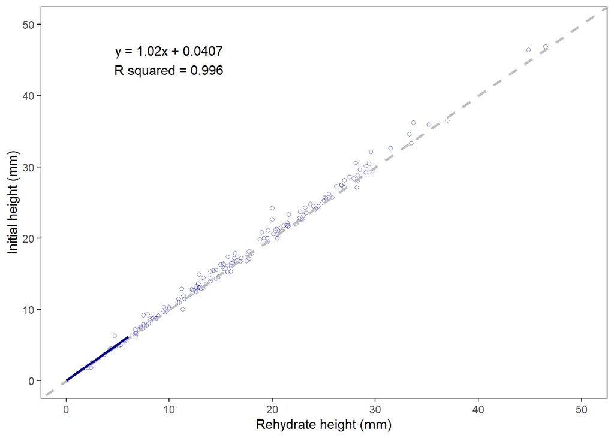

```r
     #.....Scatterplot of height_r(x) as Predictor of height_i(y).....

height_ir_plot <- ggplot() +

  # plot the raw data as points
  geom_point(data = height_all,
             aes(x = height_r,
                 y = height_i),
             alpha = 0.5,
             color = model_col,
             shape = 21) +

  # plot a 1:1 reference line
  geom_abline(slope = 1,
              intercept = 0,
              linetype = 2,
              linewidth = 1,
              color = ref_line_col) +

  # plot the confidence interval
  geom_ribbon(data = height_ir_predictions,
              aes(x = x,
                  y = predicted,
                  ymin = conf.low,
                  ymax = conf.high),
              alpha = 0.2,
              fill = model_col) +

  # plot the prediction line
  geom_line(data = height_ir_predictions,
            aes(x = x,
                y = predicted),
            color = model_col,
            linewidth = 1) +

  # labels
  labs(x = "Rehydrate height (mm)",
       y = "Initial height (mm)") +

  # controlling axes to make the plot look square
  # this makes it easier to see the difference between the model and the 1:1 line
  scale_x_continuous(breaks = seq(from = 0, to = 50, by = 10),
                     limits = c(0, 50)) +
  scale_y_continuous(breaks = seq(from = 0, to = 50, by = 10),
                     limits = c(0, 50))+
  #add equation + r squared
   annotate("text", x = 10, y = 45, label= "y = 1.02x + 0.0407
R squared = 0.996")


height_ir_plot
```

### Width

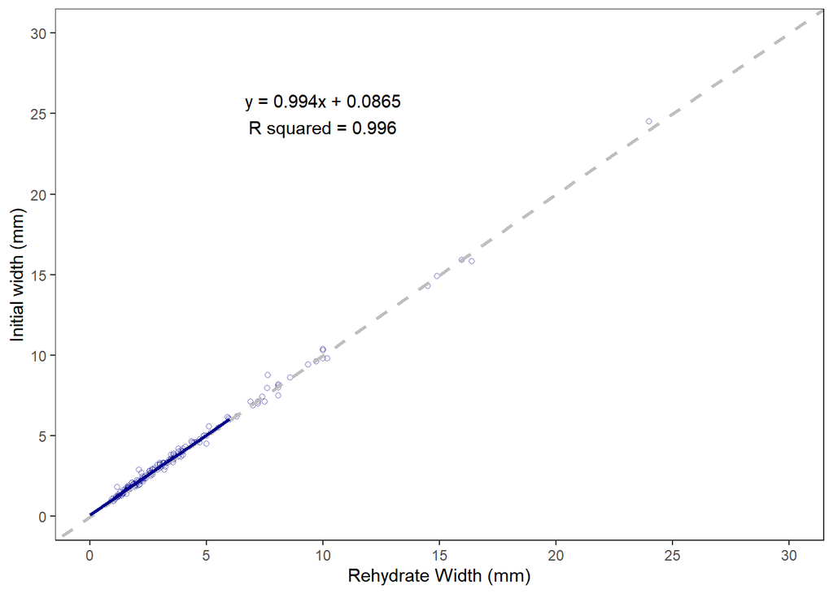

```r
     #.....Scatterplot of width_r(x) as Predictor of width_i(y).....

width_ir_plot <- ggplot() +

  # plot the raw data as points
  geom_point(data = width_all,
             aes(x = width_r,
                 y = width_i),
             alpha = 0.5,
             color = model_col,
             shape = 21) +

  # plot a 1:1 reference line
  geom_abline(slope = 1,
              intercept = 0,
              linetype = 2,
              linewidth = 1,
              color = ref_line_col) +

  # plot the confidence interval
  geom_ribbon(data = width_ir_predictions,
              aes(x = x,
                  y = predicted,
                  ymin = conf.low,
                  ymax = conf.high),
              alpha = 0.2,
              fill = model_col) +

  # plot the prediction line
  geom_line(data = width_ir_predictions,
            aes(x = x,
                y = predicted),
            color = model_col,
            linewidth = 1) +

  # labels
  labs(x = "Rehydrate Width (mm)",
       y = "Initial width (mm)") +

  # controlling axes to make the plot look square
  # this makes it easier to see the difference between the model and the 1:1 line
  scale_x_continuous(breaks = seq(from = 0, to = 30, by = 5),
                     limits = c(0, 30)) +
  scale_y_continuous(breaks = seq(from = 0, to = 30, by = 5),
                     limits = c(0, 30))+
  #add equation + r squared
   annotate("text", x = 10, y = 25, label= "y = 0.994x + 0.0865
R squared = 0.996")

width_ir_plot
```

### Thickness

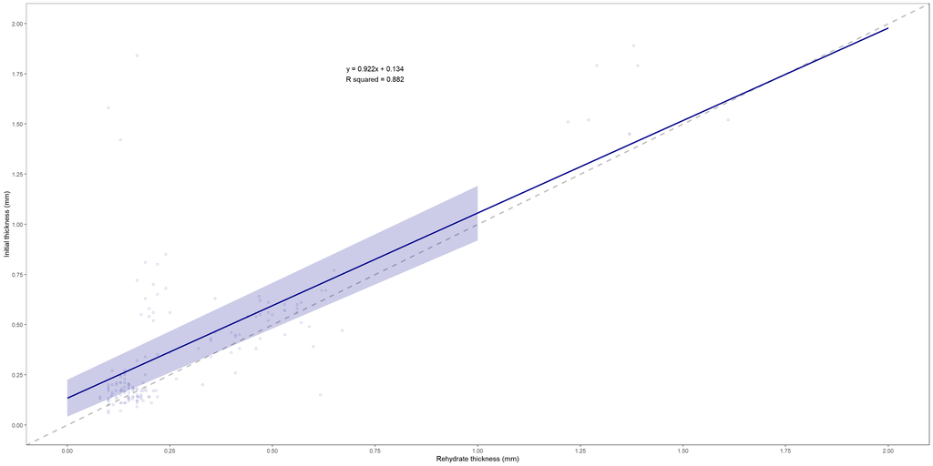

```r
     #.....Scatterplot of thickness_r(x) as Predictor of thickness_i(y).....

thick_ir_plot <- ggplot() +

  # plot the raw data as points
  geom_point(data = thickness_all,
             aes(x = thick_r,
                 y = thick_i),
             alpha = 0.5,
             color = model_col,
             shape = 21) +

  # plot a 1:1 reference line
  geom_abline(slope = 1,
              intercept = 0,
              linetype = 2,
              linewidth = 1,
              color = ref_line_col) +

  # plot the confidence interval
  geom_ribbon(data = thick_ir_predictions,
              aes(x = x,
                  y = predicted,
                  ymin = conf.low,
                  ymax = conf.high),
              alpha = 0.2,
              fill = model_col) +

  # plot the prediction line
  geom_line(data = thick_ir_predictions,
            aes(x = x,
                y = predicted),
            color = model_col,
            linewidth = 1) +

  # labels
  labs(x = "Rehydrate thickness (mm)",
       y = "Initial thickness (mm)") +

  # controlling axes to make the plot look square
  # this makes it easier to see the difference between the model and the 1:1 line
  scale_x_continuous(breaks = seq(from = 0, to = 2, by = 0.25),
                     limits = c(0, 2)) +
  scale_y_continuous(breaks = seq(from = 0, to = 2, by = 0.25),
                     limits = c(0, 2))+
  #add equation + r squared
   annotate("text", x = 0.75, y = 1.75, label= "y = 0.922x + 0.134
R squared = 0.882")

thick_ir_plot
```